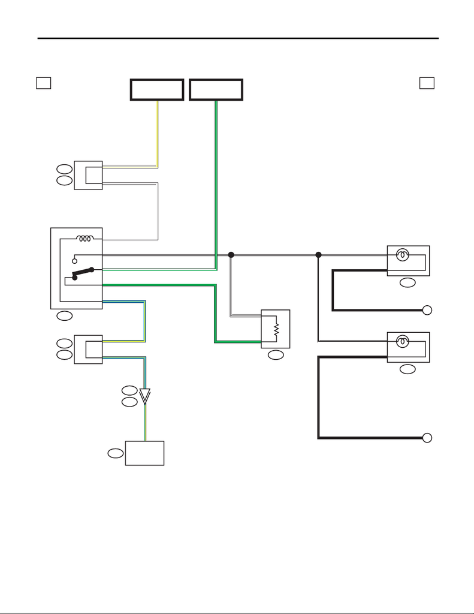

WI-253

Headlight System

WIRING SYSTEM

25.Headlight System

A: WIRING DIAGRAM

WI-44452

a a

F126

F12

B

A

F27

F125

B:

F109

C:

B360

A:

F108

D:

B361

D:

i171

i230

B552

G/W

W/Y

W/B 1

1

L/YD10 L/Y

W/B 1

B

B

B5

B5

W/Y

C16

W

B14

L/Y

A15

1

2

W/B

W/B

G

3

2

5

4

1

L/Y

G

G/W

W/B

W

L/Y

D9

BODY

INTEGRATED UNIT

DAYTIME

RUNNING LIGHT

RESISTOR

THROUGH

JOINT

CONNECTOR

HI-BEAM LH

MB-17

M/B FUSE NO. 7

MB-32

M/B FUSE NO. 15

(B)

DAYTIME

RUNNING LIGHT RELAY

THROUGH

JOINT

CONNECTOR

HI-BEAM RH

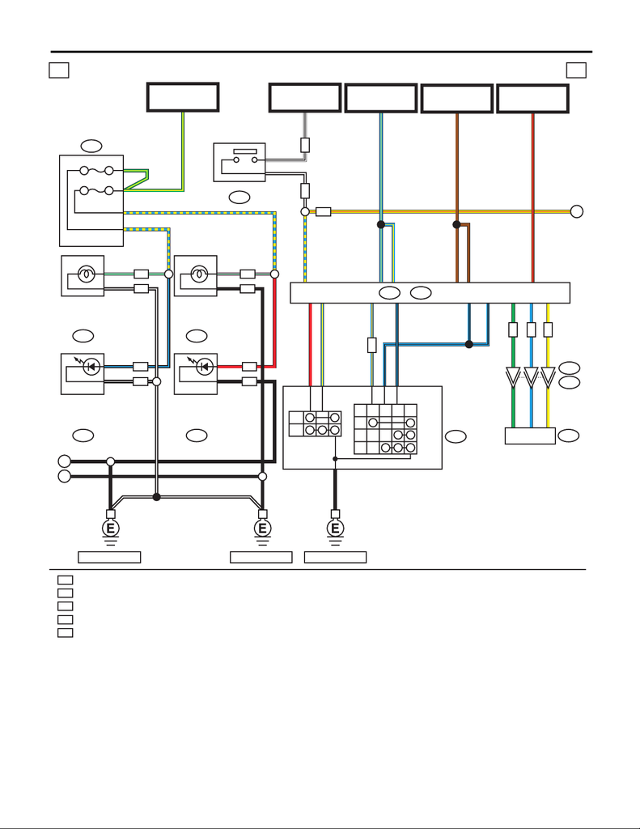

WI-254

Headlight System

WIRING SYSTEM

WI-44453

7

8

9

b b

B71

F125

F126

F126

F27

B: B281A: B280

OPOP

C

AL

HL

OP

WP

EL

LO LO

AL

HL

HL

HL

HL

B584

i238

i89

AL

AL

AL

UP

PASS

A

B555

WP

OFF

1

2

AUTO

15A

15A

GR/G

P/G8

R8

8

25 G/Y

26

11

10

B/W

W/B

G/Y

B/W

B

B

B

B/W

7

B7

Y/R

2

1

G/Y

BB

B

B

B/L

R

B/W

B

L/Y L/Y

L/Y

BR/R BR/R

W/B

A17

A3

B19

A4

B16

L/OL/O

B25

B15

L/Y

R

B17

B/LB/L

B34L/B

L/B

L/B

A34

1

2

3

BR

BR

BR

A27

B35

11

17

19

20

18

12

1

2

3

GG

LL

YY

A29

A19

B1

3

1

2

EL

B7

EL

F125

LO LO

B/L8

EL

B/W7

EL

AUTO LIGHT SENSOR

MB-13

HEADLIGHT RELAY

MB-28

M/B FUSE NO. 14

(B)

MB-18

HEADLIGHT RELAY

MB-12

HEADLIGHT RELAY

MB-16

M/B FUSE NO. 6

LIGHTING

SWITCH

: EXCEPT FOR HALOGEN MODEL

: WITH PUSH BUTTON START

: WITHOUT PUSH BUTTON START

: HALOGEN MODEL

: WITH AUTO LIGHT

KEY WARNING SWITCH

RELAY HOLDER

FRONT

COMBINATION

LIGHT RH

(HEADLIGHT)

FRONT

COMBINATION

LIGHT LH

(HEADLIGHT)

FRONT

COMBINATION

LIGHT RH

(HEADLIGHT)

FRONT

COMBINATION

LIGHT LH

(HEADLIGHT)

COMBINATION

SWITCH

DIMMER &

PASSING

SWITCH

BODY INTEGRATED UNIT

: HALOGEN MODEL : P/G

EXCEPT FOR HALOGEN MODEL : R

: HALOGEN MODEL : GR/G

EXCEPT FOR HALOGEN MODEL : B/L

: WITHOUT PUSH BUTTON START : B/W

WITH PUSH BUTTON START : Y/R

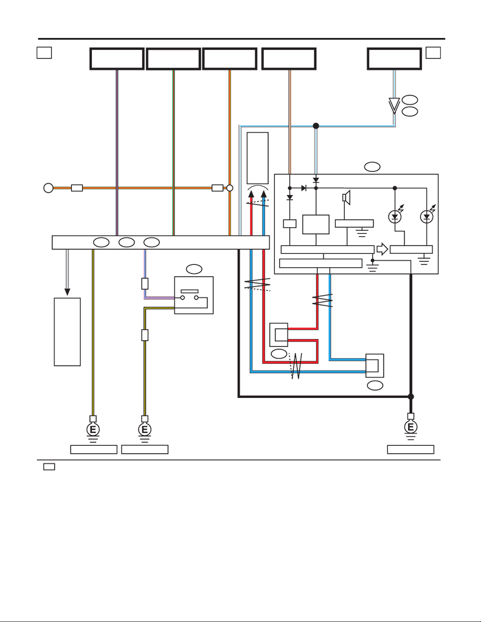

WI-255

Headlight System

WIRING SYSTEM

WI-44454

3

c c

B116

i84

C:

B281

B:

B280

A:

i233

i229

B551

CVTCVT

i10

WPWP

C

WP

I/F

J/C

i232

J/C

1

1

1

1

L

R

R

L

B

P/L

B/Y

Y/R

1

2

38B

20

R

L

B

B/YB/Y A1

C35

BC1

C27

L

RB20

B28

BR/W

GR C32

P/L B18

W/LC6

G/R G/RB3

Y/R Y/RA32

W/LW/L

BR/W

40 W/L

R33

L32

L/RB7 L/R

B/Y

1

SPEAKER

DRIVE CIRCUIT

REF. TO PARKING BRAKE /

BRAKE FLUID LEVEL

WARNING LIGHT SYSTEM

[a]

POWER

SUPPLY

CIRCUIT

MICRO COMPUTER

CAN TRANSCEIVER & RECEIVER

DRIVE CIRCUIT

LIGHTING

HI-BEAM

FB-29

F/B FUSE NO. 31

(ACC)

FB-18

F/B FUSE NO. 7

(B)

FB-12

F/B FUSE NO. 2

(IG)

FB-38

F/B FUSE NO. 12

(IG)

MB-29

M/B FUSE NO. 8

(B)

: WITH PUSH BUTTON START

P RANGE

SWITCH

SELECT

LEVER

REF. TO CAN

COMMUNICATION

SYSTEM [b]

COMBINATION METER

BODY INTEGRATED UNIT

: TERMINAL No. OPTIONAL ARRANGEMENT

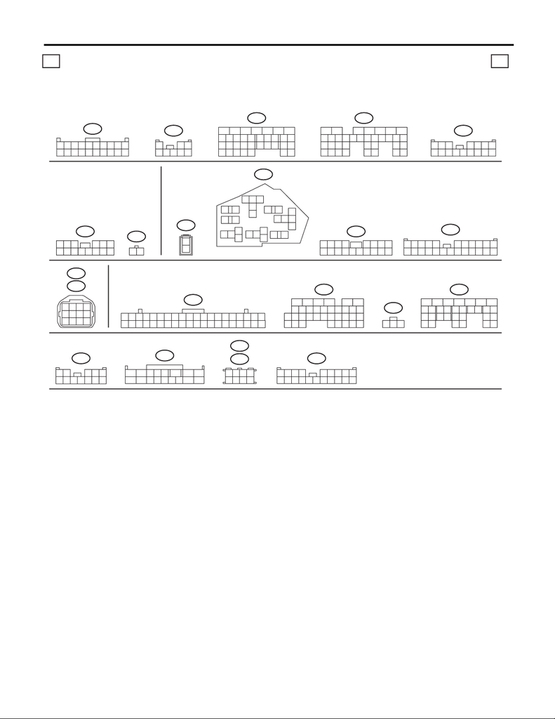

WI-256

Headlight System

WIRING SYSTEM

10 11

12 13 14 15 16 17 18 19 20 21 22 23 24

567

F109

B:

F108

(GR)

1

9

23 8

10

4

11 12 13 14 15 16

567

17 18

A:

i230

(GR)

10

13

345 6

14 15 16 17

1211

12 78

9

i233

i232

78

5

6

34

21

WI-44455

d d

i10

11 12

9

10

7856341

2

15 1613 14 19

18

20

21 22 23 24 26

25

17

D:

(GR)

B361

123 456

789

10 11 12 13 14

F126

(GR)

F125

(GR)

1234

5678

9

10 11 12

C:

(GR)

B360

123 4567

89

10 11 12 13 14 15 16

B71

123456789

10

11 12 13 14 15 16 17 18 19 20

B116

123

45678

B280

18

2719 20 21 22

23

26

24

25

28 29 3332 3430 31

98

15

1413121110

17

16

1234567

A:

B281B:

5672134

29

10 11 12 13 14 15

2524

16

30

98

17 18 19

20

28

21 22 23

3231

26 27

33 34 35

B555

12

F27

24

23

25

12 13 14

15

16

26

2221

20

19

1817

10 11

2

4

5

13

7698

i84C:

19

18

21

20

2322 24 25 26

17

1

23

4

56

27

28 29 30

31 32 33 34 35

798

151413121110 16

i89

123

i171D:

19

18

20 21

22

23

26

24

25

27

28 29

30 31

98

15

1413121110

17

16

1234567

i229

12 345

6789

10 11 12

F12

1

2

(B)

89

19 20

1234 567

10 11 12 13 14 15 16 17 18

i238

RELAY HOLDER

LIST OF CONNECTORS